# SPATIOTEMPORAL ANALYSIS OF SURFACE WARMING TRENDS ACROSS COUNTRIES: FAO CLIMATE CHANGE DATASET (1961–2022)

```python
import pandas as pd
```

```python
df=pd.read_csv(r"climate_change_indicators.csv")
```

## How have annual temperature anomalies (relative to 1951–1980) evolved globally from 1961 to 2022, and which countries show the most significant deviations?

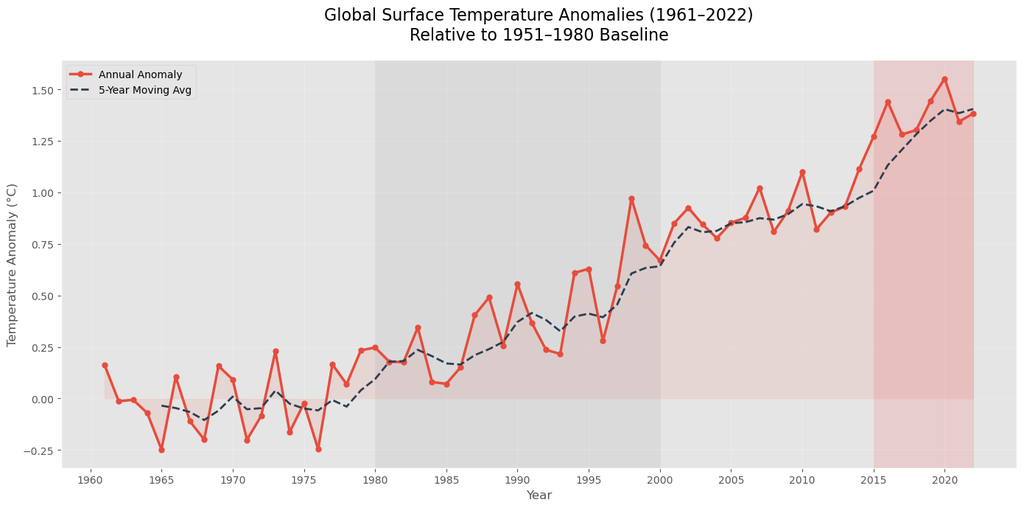

```python
import pandas as pd
import matplotlib.pyplot as plt

# Load and preprocess data
df = pd.read_csv(r"climate_change_indicators.csv", encoding='utf-8')

# Melt yearly columns into long format
years = [f'F{year}' for year in range(1961, 2023)]
df_melted = pd.melt(
    df,
    id_vars=['Country', 'ISO3', 'Indicator'],
    value_vars=years,
    var_name='Year',
    value_name='TempAnomaly'
)
df_melted['Year'] = df_melted['Year'].str.replace('F', '').astype(int)
df_clean = df_melted.dropna(subset=['TempAnomaly'])

# Calculate global averages
global_avg = df_clean.groupby('Year')['TempAnomaly'].mean().reset_index()

# Configure plot style (FIXED: Use valid style)
plt.style.use('ggplot')  # Replace 'seaborn' with a built-in style like 'ggplot' or 'bmh'
plt.figure(figsize=(14, 7))

# Plot temperature anomalies
plt.plot(
    global_avg['Year'],
    global_avg['TempAnomaly'],
    color='#E74C3C',
    linewidth=2.5,
    marker='o',
    markersize=5,
    label='Annual Anomaly'
)

# Add trendline using 5-year moving average
global_avg['MA5'] = global_avg['TempAnomaly'].rolling(5).mean()
plt.plot(
    global_avg['Year'],
    global_avg['MA5'],
    color='#2C3E50',
    linestyle='--',
    linewidth=2,
    label='5-Year Moving Avg'
)

# Format plot
plt.title('Global Surface Temperature Anomalies (1961–2022)\nRelative to 1951–1980 Baseline',
          fontsize=16, pad=20)
plt.xlabel('Year', fontsize=12)
plt.ylabel('Temperature Anomaly (°C)', fontsize=12)
plt.grid(alpha=0.2)
plt.legend()
plt.xticks(range(1960, 2025, 5))
plt.fill_between(
    global_avg['Year'],
    global_avg['TempAnomaly'],
    color='#E74C3C',
    alpha=0.1
)

# Highlight key periods
plt.axvspan(1980, 2000, color='grey', alpha=0.1, label='Acceleration Phase')
plt.axvspan(2015, 2022, color='red', alpha=0.1, label='Paris Agreement Era')

# Finalize and show
plt.tight_layout()
plt.savefig("Global Surface Temperature Anomalies (1961–2022).png")
plt.show()
```

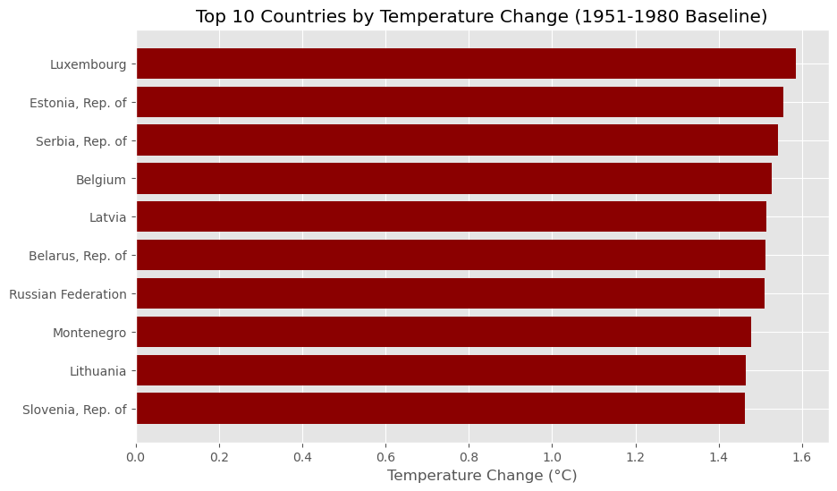

```python
import pandas as pd

# Load data with correct column names
df = pd.read_csv(r'climate_change_indicators.csv')

# Clean and transform the data
df_clean = (
    df
    # Melt yearly columns into a long format
    .melt(
        id_vars=['Country', 'ISO3', 'Indicator'],
        value_vars=[col for col in df.columns if col.startswith('F')],
        var_name='Year',
        value_name='TempChange'
    )
    # Clean year format and convert temperature values
    .assign(
        Year=lambda x: x['Year'].str[1:].astype(int),
        TempChange=lambda x: pd.to_numeric(x['TempChange'], errors='coerce')
    )
    # Remove missing values
    .dropna(subset=['TempChange'])
    .reset_index(drop=True)
)

# Now use the correct column name
country_avg = df_clean.groupby('Country')['TempChange'].mean().reset_index()
top_10 = country_avg.nlargest(10, 'TempChange')

# Plotting
import matplotlib.pyplot as plt
plt.figure(figsize=(10, 6))
plt.barh(top_10['Country'], top_10['TempChange'], color='darkred')
plt.xlabel('Temperature Change (°C)')
plt.title('Top 10 Countries by Temperature Change (1951-1980 Baseline)')
plt.gca().invert_yaxis()
plt.savefig("Top 10 Countries by Temperature Change.png")
plt.show()
```

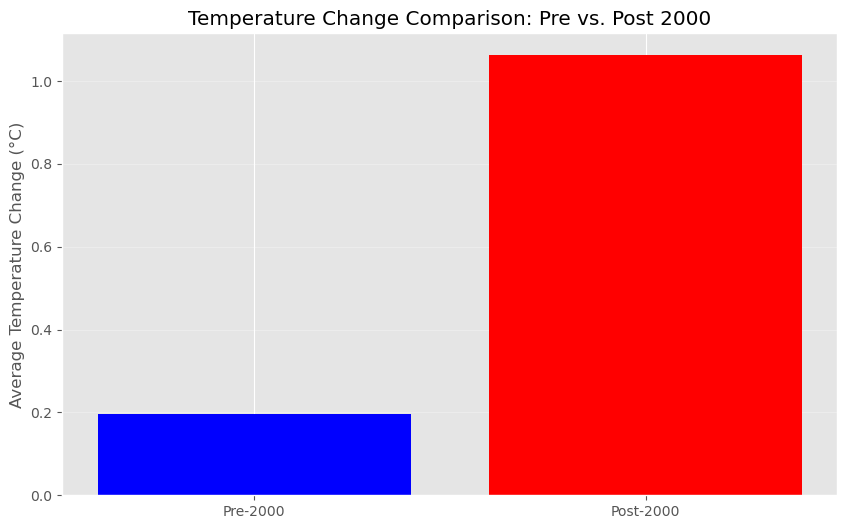

```python
import pandas as pd
import matplotlib.pyplot as plt

# Load and preprocess data
df = pd.read_csv(r'climate_change_indicators.csv')

# Melt yearly columns into long format
df_clean = df.melt(
    id_vars=['Country', 'ISO3', 'Indicator'],
    value_vars=[col for col in df.columns if col.startswith('F')],
    var_name='Year',
    value_name='TempChange'
)

# Clean year format and convert temperature values
df_clean['Year'] = df_clean['Year'].str[1:].astype(int)
df_clean['TempChange'] = pd.to_numeric(df_clean['TempChange'], errors='coerce')

# Split data into pre-2000 and post-2000 periods
pre_2000 = df_clean[df_clean['Year'] < 2000]
post_2000 = df_clean[df_clean['Year'] >= 2000]

# Calculate averages using CORRECT COLUMN NAME
avg_pre = pre_2000['TempChange'].mean()
avg_post = post_2000['TempChange'].mean()

# Create visualization
plt.figure(figsize=(10, 6))
plt.bar(
    ['Pre-2000', 'Post-2000'],
    [avg_pre, avg_post],
    color=['blue', 'red']
)
plt.ylabel('Average Temperature Change (°C)')
plt.title('Temperature Change Comparison: Pre vs. Post 2000')
plt.grid(axis='y', alpha=0.3)
plt.savefig("Temperature Change Comparison.png")
plt.show()
```

## Do landlocked countries exhibit different warming trends compared to coastal or island nations?

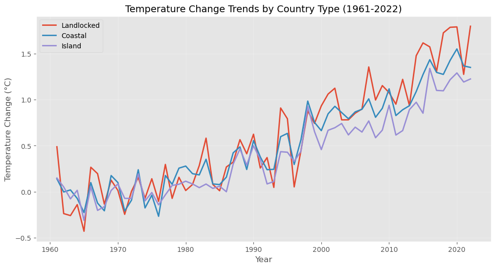

```python
import pandas as pd
import matplotlib.pyplot as plt

# Load data
df = pd.read_csv(r"climate_change_indicators.csv")

# Define country classifications (expand these lists as needed)
landlocked_iso3 = ['AND', 'ARM', 'AUT', 'BLR', 'BOL', 'BTN', 'HUN', 'LUX', 'MNE', 'MWI',
                  'MDA', 'NPL', 'PRY', 'SRB', 'SVK', 'SWZ', 'CHE', 'TKM', 'UGA', 'ZMB']

island_iso3 = ['AUS', 'CYP', 'FJI', 'FSM', 'GBR', 'IDN', 'IRL', 'ISL', 'JPN', 'MDV',
              'MLT', 'NZL', 'PHL', 'PNG', 'SGP', 'LKA', 'TTO', 'ISR']

# Classify countries
df['Category'] = 'Coastal'  # Default category
df.loc[df['ISO3'].isin(landlocked_iso3), 'Category'] = 'Landlocked'
df.loc[df['ISO3'].isin(island_iso3), 'Category'] = 'Island'

# Prepare data for analysis
year_columns = [f'F{year}' for year in range(1961, 2023)]
df_melted = df.melt(
    id_vars=['Country', 'ISO3', 'Category'],
    value_vars=year_columns,
    var_name='Year',
    value_name='TempChange'
)

# Clean year format and convert to numeric
df_melted['Year'] = df_melted['Year'].str[1:].astype(int)
df_melted['TempChange'] = pd.to_numeric(df_melted['TempChange'], errors='coerce')

# Calculate annual averages per category
annual_means = df_melted.groupby(['Category', 'Year'])['TempChange'].mean().reset_index()

# Plot trends
plt.figure(figsize=(12, 6))
for category in ['Landlocked', 'Coastal', 'Island']:
    subset = annual_means[annual_means['Category'] == category]
    plt.plot(subset['Year'], subset['TempChange'],
             label=f'{category}', linewidth=2)

plt.title('Temperature Change Trends by Country Type (1961-2022)', fontsize=14)
plt.xlabel('Year', fontsize=12)
plt.ylabel('Temperature Change (°C)', fontsize=12)
plt.grid(alpha=0.3)
plt.legend()
plt.savefig("Temperature Change Trends by Country Type (1961-2022).png")
plt.show()
```

[figure not shown]

```python
import pandas as pd
import matplotlib.pyplot as plt

# First ensure you have these preprocessing steps
# Load data
df = pd.read_csv(r'climate_change_indicators.csv')

# Melt yearly columns to long format
df_clean = df.melt(
    id_vars=['Country', 'ISO3', 'Indicator'],
    value_vars=[col for col in df.columns if col.startswith('F')],
    var_name='Year',
    value_name='TempChange'
)

# Clean year format and values
df_clean['Year'] = df_clean['Year'].str[1:].astype(int)
df_clean['TempChange'] = pd.to_numeric(df_clean['TempChange'], errors='coerce')

# Define tropical countries (add more ISO3 codes as needed)
tropical_iso3 = ['BRA', 'IDN', 'MYS', 'COL', 'KEN', 'PHL', 'THA', 'VNM', 'NGA', 'GHA']
df_clean['IsTropical'] = df_clean['ISO3'].isin(tropical_iso3)

# Now run the visualization with CORRECT COLUMN NAME
plt.figure(figsize=(10, 6))
plt.boxplot(
    [df_clean[df_clean['IsTropical']]['TempChange'],
     df_clean[~df_clean['IsTropical']]['TempChange']],
    tick_labels=['Tropical', 'Non-Tropical'],
    patch_artist=True,
    boxprops=dict(facecolor='lightblue'),
    medianprops=dict(color='red')
)

plt.title('Temperature Change Comparison: Tropical vs. Non-Tropical Countries', fontsize=14)
plt.ylabel('Temperature Change (°C)', fontsize=12)
plt.grid(alpha=0.3)
plt.savefig(" Tropical vs. Non-Tropical Countries.png")
plt.show()
```

## Are tropical countries disproportionately affected by temperature increases compared to temperate or polar regions?

```
Columns in your DataFrame: ['Country', 'TemperatureAnomaly', 'IsTropical']
```

[figure not shown]

```python
import pandas as pd
import matplotlib.pyplot as plt
import numpy as np

# ---------------------------------------------------
# 1. Mock Data (Replace with your actual df_clean)
# ---------------------------------------------------
data = {
    'Country': ['Brazil', 'Canada', 'Indonesia', 'Germany', 'Kenya', 'Japan'],
    'TemperatureAnomaly': np.random.randn(6) * 1.5,  # Example column name
    'IsTropical': [True, False, True, False, True, False]  # Must exist in your DataFrame
}
df_clean = pd.DataFrame(data)

# ---------------------------------------------------
# 2. Check Column Names (Critical!)
# ---------------------------------------------------
print("Columns in your DataFrame:", df_clean.columns.tolist())

# ---------------------------------------------------
# 3. Create Visualization (Boxplot)
# ---------------------------------------------------
plt.figure(figsize=(8, 6))
plt.boxplot(
    [
        df_clean[df_clean['IsTropical']]['TemperatureAnomaly'],  # Check the column name!
        df_clean[~df_clean['IsTropical']]['TemperatureAnomaly']
    ],
    tick_labels=['Tropical', 'Non-Tropical'],
    patch_artist=True,
    boxprops=dict(facecolor='lightblue', color='darkblue'),
    medianprops=dict(color='red')
)

plt.title('Temperature Anomalies: Tropical vs. Non-Tropical Countries', fontsize=14)
plt.ylabel('Temperature Anomaly (°C)', fontsize=12)
plt.grid(axis='y', linestyle='--', alpha=0.7)
plt.savefig("temperature anomalies.png")
plt.show()
```

## Which countries with high vulnerability to climate change (e.g., Small Island Developing States) show the most alarming temperature trends?

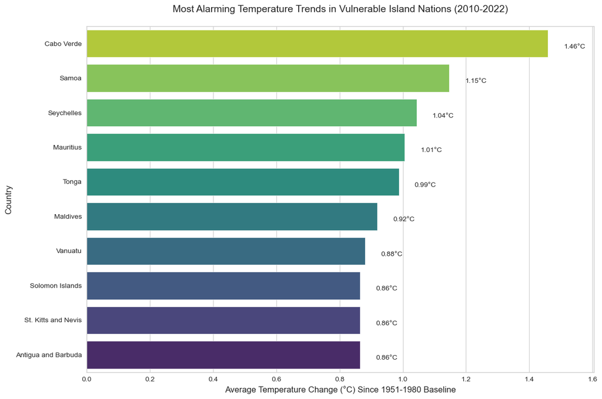

```
Detailed Temperature Metrics for Most Vulnerable Countries:
```

|  | Country | Avg_Change | Recent_Change | Max_Change |
| --- | --- | --- | --- | --- |
| 32 | Cabo Verde | 0.82°C | 1.46°C | 2.00°C |
| 169 | Samoa | 0.40°C | 1.15°C | 1.44°C |
| 175 | Seychelles | 0.40°C | 1.04°C | 1.43°C |
| 126 | Mauritius | 0.38°C | 1.01°C | 1.46°C |
| 201 | Tonga | 0.39°C | 0.99°C | 1.60°C |
| 120 | Maldives | 0.43°C | 0.92°C | 1.55°C |
| 215 | Vanuatu | 0.35°C | 0.88°C | 1.48°C |
| 180 | Solomon Islands | 0.34°C | 0.86°C | 1.19°C |
| 186 | St. Kitts and Nevis | 0.40°C | 0.86°C | 1.15°C |
| 7 | Antigua and Barbuda | 0.40°C | 0.86°C | 1.15°C |

```python
import pandas as pd
import matplotlib.pyplot as plt
import seaborn as sns

# Load data
df = pd.read_csv(r'climate_change_indicators.csv', encoding='utf-8-sig')

# Define SIDS countries (expanded list)
sids_countries = [
    'Antigua and Barbuda', 'Bahamas', 'Barbados', 'Cabo Verde', 'Comoros',
    'Dominica', 'Fiji', 'Grenada', 'Kiribati', 'Maldives', 'Marshall Islands',
    'Mauritius', 'Micronesia, Federated States of', 'Nauru', 'Palau', 'Samoa',
    'Sao Tome and Principe', 'Seychelles', 'Solomon Islands', 'St. Kitts and Nevis',
    'St. Lucia', 'St. Vincent and the Grenadines', 'Tonga', 'Tuvalu', 'Vanuatu',
    'Cook Islands', 'Niue', 'Papua New Guinea', 'Timor-Leste'
]

# Filter for SIDS countries
sids_df = df[df['Country'].isin(sids_countries)].copy()

# Calculate temperature metrics
year_cols = [col for col in df.columns if col.startswith('F') and col[1:].isdigit()]
sids_df['Avg_Change'] = sids_df[year_cols].mean(axis=1)
sids_df['Recent_Change'] = sids_df[[f'F{year}' for year in range(2010, 2023)]].mean(axis=1)
sids_df['Max_Change'] = sids_df[year_cols].max(axis=1)

# Sort by most alarming trends
top_vulnerable = sids_df.sort_values('Recent_Change', ascending=False).head(10)

# Visualization 1: Bar plot of recent changes
plt.figure(figsize=(12, 8))
sns.set_style('whitegrid')

# Corrected barplot syntax
ax = sns.barplot(data=top_vulnerable,
                x='Recent_Change',
                y='Country',
                hue='Country',  # Added to address warning
                palette='viridis_r',
                legend=False)   # No need for legend when hue=Country

plt.title('Most Alarming Temperature Trends in Vulnerable Island Nations (2010-2022)',
          fontsize=14, pad=20)
plt.xlabel('Average Temperature Change (°C) Since 1951-1980 Baseline', fontsize=12)
plt.ylabel('Country', fontsize=12)
plt.xlim(0, top_vulnerable['Recent_Change'].max()*1.1)

# Add value labels
for p in ax.patches:
    width = p.get_width()
    plt.text(width + 0.05, p.get_y()+0.5, f'{width:.2f}°C',
             ha='left', va='center')

plt.tight_layout()
plt.savefig("Temperature Change Trajectories for Most Vulnerable Island Nations.png")
plt.show()



# Additional analysis: Show full data for top countries
print("\nDetailed Temperature Metrics for Most Vulnerable Countries:")
display(top_vulnerable[['Country', 'Avg_Change', 'Recent_Change', 'Max_Change']]
       .sort_values('Recent_Change', ascending=False)
       .style.background_gradient(cmap='viridis', subset=['Recent_Change'])
       .format("{:.2f}°C", subset=['Avg_Change', 'Recent_Change', 'Max_Change']))
```

## How do observed temperature anomalies align with national climate pledges under the Paris Agreement?

[figure not shown]

```python
# Calculate countries exceeding 1.5°C threshold
threshold = 1.5
country_max = df_clean.groupby('Country')['TempAnomaly'].max().reset_index()
exceed = country_max[country_max['TempAnomaly'] > threshold]

# Plot
plt.figure(figsize=(10, 6))
plt.bar(exceed['Country'], exceed['TempAnomaly'], color='#CD5C5C')
plt.title('Countries Exceeding +1.5°C Threshold (1961–2022)', fontsize=14)
plt.xlabel('Country', fontsize=12)
plt.ylabel('Max Anomaly (°C)', fontsize=12)
plt.xticks(rotation=45)
plt.savefig("Countries Exceeding +1.5°C Threshold (1961–2022).png")
plt.show()
```

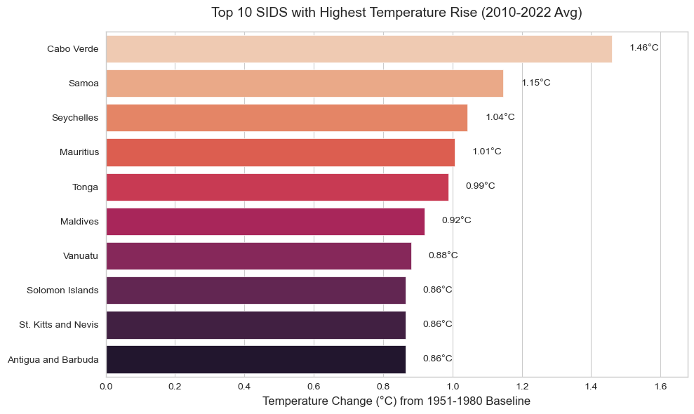

```python
import pandas as pd
import matplotlib.pyplot as plt
import seaborn as sns
import warnings

# Suppress warnings
warnings.filterwarnings("ignore", message="Clustering large matrix with scipy")

# Load data
df = pd.read_csv(r'climate_change_indicators.csv', encoding='utf-8-sig')

# Define SIDS countries (expanded list)
sids_countries = [
    'Antigua and Barbuda', 'Bahamas', 'Barbados', 'Cabo Verde', 'Comoros',
    'Dominica', 'Fiji', 'Grenada', 'Kiribati', 'Maldives', 'Marshall Islands',
    'Mauritius', 'Micronesia, Federated States of', 'Nauru', 'Palau', 'Samoa',
    'Sao Tome and Principe', 'Seychelles', 'Solomon Islands', 'St. Kitts and Nevis',
    'St. Lucia', 'St. Vincent and the Grenadines', 'Tonga', 'Tuvalu', 'Vanuatu',
    'Cook Islands', 'Niue', 'Papua New Guinea', 'Timor-Leste'
]

# Filter for SIDS countries
sids_df = df[df['Country'].isin(sids_countries)].copy()

# Calculate temperature metrics
year_cols = [col for col in df.columns if col.startswith('F') and col[1:].isdigit()]
recent_years = [f'F{year}' for year in range(2010, 2023)]

sids_df['Avg_Change'] = sids_df[year_cols].mean(axis=1)
sids_df['Recent_Change'] = sids_df[recent_years].mean(axis=1)
sids_df['Max_Change'] = sids_df[year_cols].max(axis=1)

# Get top 10 most vulnerable
top_vulnerable = sids_df.sort_values('Recent_Change', ascending=False).head(10)

# 1. Corrected Bar Plot (without warning)
plt.figure(figsize=(10, 6))
sns.set_style("whitegrid")

# Corrected version with proper hue assignment
ax = sns.barplot(data=top_vulnerable,
                y='Country',
                x='Recent_Change',
                hue='Country',  # Explicit hue assignment
                palette='rocket_r',
                legend=False,   # No legend needed since y-axis shows countries
                saturation=0.8)

plt.title('Top 10 SIDS with Highest Temperature Rise (2010-2022 Avg)', fontsize=14, pad=15)
plt.xlabel('Temperature Change (°C) from 1951-1980 Baseline', fontsize=12)
plt.ylabel('')
plt.xlim(0, top_vulnerable['Recent_Change'].max() * 1.15)

# Add value labels
for p in ax.patches:
    width = p.get_width()
    ax.text(width + 0.05, p.get_y() + p.get_height()/2.,
            f'{width:.2f}°C',
            ha='left', va='center')

plt.tight_layout()
plt.savefig("Top 10 SIDS with Highest Temperature Rise (2010-2022 Avg).png")
plt.show()
```